# FMT_Concrete_Project

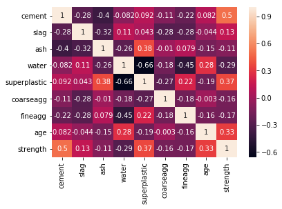

```python
corr_DF = data.corr()
sns.heatmap(corr_DF, annot = True)
```

**Normalize Data**

```python
data_to_normalize = data.iloc[:,:-1]
scaler = MinMaxScaler()
scaler.fit_transform(data_to_normalize)
```

```
array([[0.08972603, 0.58987201, 0.        , ..., 0.49651163, 0.38760662,
        0.07417582],
       [0.15273973, 0.11741792, 0.62118941, ..., 0.81337209, 0.50727546,
        0.03571429],
       [0.33789954, 0.        , 0.47826087, ..., 0.45319767, 0.67034621,
        0.07417582],
       ...,
       [0.39817352, 0.32276016, 0.45127436, ..., 0.20087209, 0.43728048,
        0.07417582],
       [0.54794521, 0.10573178, 0.        , ..., 0.38081395, 0.19066734,
        0.73901099],
       [1.        , 0.        , 0.        , ..., 0.94186047, 0.04766683,
        0.01648352]])
```

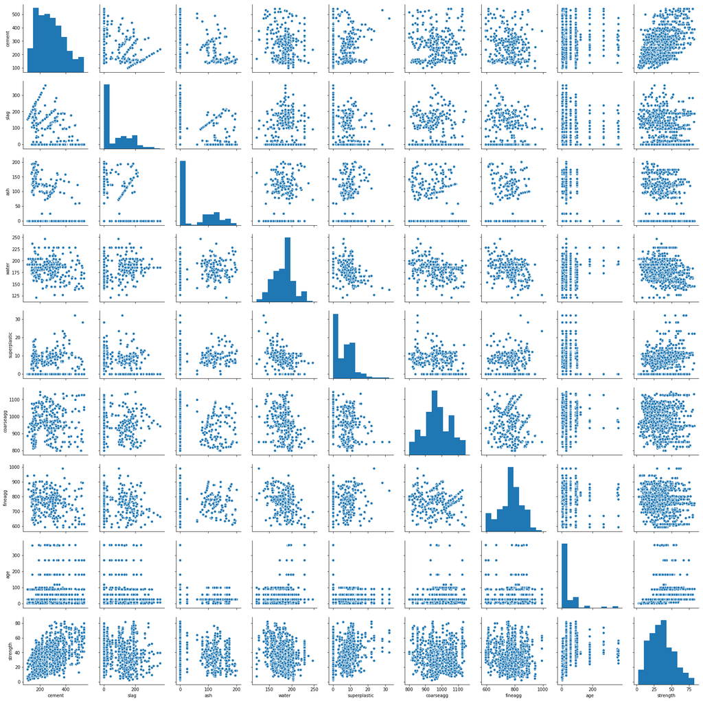

```python
data_to_normalize['strength'] = data['strength']
sns.pairplot(data_to_normalize)
```

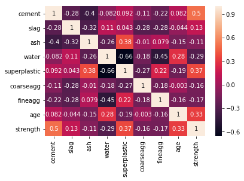

```python
corr_normalised_Data = data_to_normalize.corr()
sns.heatmap(corr_normalised_Data, annot = True)
```

We can see that 'cement' has the highest correlation with the area of 'strength'(which is a positive correlation), followed by 'superplasticizer', which is also a positive correlation, 'fly_ash' has the least correlation.

It is evident that cement and age, superplastic have good positive corr with strength, cement being the strong predictor Water has a good negative correlation with Strength, where are there are other variables with very less correlation there are good correlation amng variables : cement -> Slag = -ve relation and strength-> +ve Slag -> ash and fineaggg = -ve Water -> superplastic , fineagg strength = -ve superplastic -> ash and Strength positive correlation between water and slag age -> Strength and water.

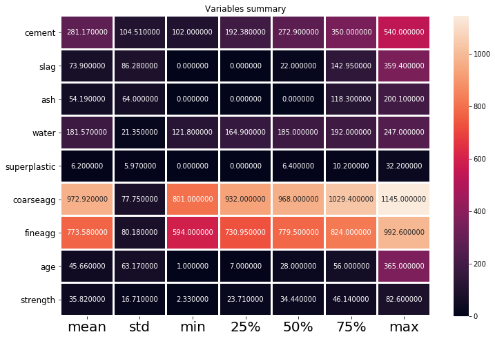

```python
plt.figure(figsize=(12,8))
sns.heatmap(round(data.describe()[1:].transpose(),2),linewidth=2,annot=True,fmt="f")
plt.xticks(fontsize=20)
plt.yticks(fontsize=12)
plt.title("Variables summary")
plt.show()
```

**Age and Category Distributions**

```python
def label(data):
    if data["age"] <= 30:
        return "1 month"
    if data["age"] > 30 and data["age"] <= 60 :
        return "2 months"
    if data["age"] > 60 and data["age"] <= 90 :
        return "3 months"
    if data["age"] > 90 and data["age"] <= 120 :
        return "4 months"
    if data["age"] > 120 and data["age"] <= 150 :
        return "5 months"
    if data["age"] > 150 and data["age"] <= 180 :
        return "6 months"
    if data["age"] > 180 and data["age"] <= 210 :
        return "7 months"
    if data["age"] > 210 and data["age"] <= 240 :
        return "8 months"
    if data["age"] > 240 and data["age"] <= 270 :
        return "9 months"
    if data["age"] > 270 and data["age"] <= 300 :
        return "10 months"
    if data["age"] > 300 and data["age"] <= 330 :
        return "11 months"
    if data["age"] > 330 :
        return "12 months"
data["age_months"] = data.apply(lambda data:label(data) , axis=1)
```

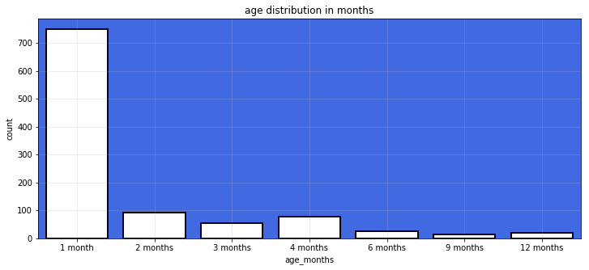

```python
plt.figure(figsize=(12,5))
order = ['1 month','2 months', '3 months','4 months','6 months','9 months', '12 months']
ax = sns.countplot(data["age_months"],
                   order=order,linewidth=2,
                   edgecolor = "k"*len(order),
                   palette=["w"])
ax.set_facecolor("royalblue")
plt.title("age distribution in months")
plt.grid(True,alpha=.3)
plt.show()
```

```python
df2 = data.copy(deep=True)
def lab(data2):
    if data2["strength"] <= 17:
        return "category 1"
    if data2["strength"] >17 and data2["strength"] <= 28 :
        return "category 2"
    if data2["strength"] >28 :
        return "category 3"

data["strength_category"] = data.apply(lambda data:lab(data) ,axis =1)
```

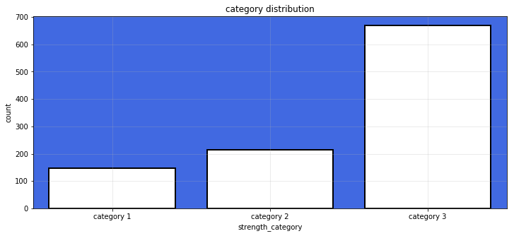

```python
plt.figure(figsize=(12,5))
order = ['category 1','category 2', 'category 3']
ax = sns.countplot(data["strength_category"],
                   order=order,linewidth=2,
                   edgecolor = "k"*len(order),
                   palette=["w"])
ax.set_facecolor("royalblue")
plt.title("category distribution")
plt.grid(True,alpha=.3)
plt.show()
```

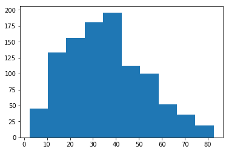

```python
plt.hist((data.strength))
```

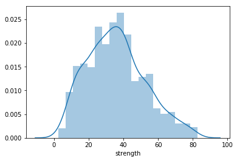

```python
sns.distplot(data['strength'])
```

```python
# The target variable has the distribution of data to be almost normal, but with lesser values on higher range, / higher values on lesser range
# Let us check the skewness:
print("Skewness = ",data['strength'].skew())
```

```
Skewness =  0.41697728841071807
```

It is positively, lightly skewed, as the skew value is < 0.5. For analysis, we can log transform this variable for better analysis, optional.

**Feature Engineering Techniques**

```python
dataset = data.values


X = dataset[:,0:8]
Y = dataset[:,8]

data=data.drop(['age_months'], axis = 1)
data=data.drop(['strength_category'], axis = 1)
print(data.columns)
```

```
Index(['cement', 'slag', 'ash', 'water', 'superplastic', 'coarseagg',
       'fineagg', 'age', 'strength'],
      dtype='object')
```

**Feature selection with RFE**

```python
from sklearn.feature_selection import RFE

from sklearn.ensemble import RandomForestRegressor
from sklearn.linear_model import LinearRegression

from sklearn.tree import DecisionTreeRegressor

#Feature Selection with RandomForest Regressor
model = RandomForestRegressor()
rfe = RFE(model, 3)
fit = rfe.fit(X, Y)
f = rfe.get_support(1) #the most important features

print("\n Number of Features with RandomForest Regressor : ", fit.n_features_)
print("Selected Features with RandomForest Regressor: ", data.columns[f])
print("Feature Ranking with RandomForest Regressor: ", fit.ranking_)

#Feature Selection with Linear Regression
model = LinearRegression()
rfe = RFE(model, 3)
fit = rfe.fit(X, Y)
f = rfe.get_support(1) #the most important features

print("\n Number of Features with Linear Regressor: ", fit.n_features_)
print("Selected Features with Linear Regressor: ", data.columns[f])
print("Feature Ranking with Linear Regressor : ", fit.ranking_)



#Feature Selection with DecisionTree Regression
model = DecisionTreeRegressor()
rfe = RFE(model, 3)
fit = rfe.fit(X, Y)
f = rfe.get_support(1) #the most important features

print("\n Number of Features with DecisionTree Regressor : ", fit.n_features_)
print("Selected Features with DecisionTree Regressor: ", data.columns[f])
print("Feature Ranking with DecisionTree Regressor : ", fit.ranking_)
```

```
 Number of Features with RandomForest Regressor :  3
Selected Features with RandomForest Regressor:  Index(['cement', 'water', 'age'], dtype='object')
Feature Ranking with RandomForest Regressor:  [1 2 6 1 3 5 4 1]

 Number of Features with Linear Regressor:  3
Selected Features with Linear Regressor:  Index(['water', 'superplastic', 'age'], dtype='object')
Feature Ranking with Linear Regressor :  [2 3 4 1 1 6 5 1]

 Number of Features with DecisionTree Regressor :  3
Selected Features with DecisionTree Regressor:  Index(['cement', 'water', 'age'], dtype='object')
Feature Ranking with DecisionTree Regressor :  [1 2 6 1 4 3 5 1]
```

```python
from sklearn.linear_model import Lasso,Ridge
from sklearn.linear_model import ElasticNet

model = Lasso()
rfe = RFE(model,3)
fit = rfe.fit(X, Y)
f = rfe.get_support(1) #the most important features


print("Number of Features with Lasso : ", fit.n_features_)
print("Selected Features with Lasso: ", data.columns[f])
print("Feature Ranking with Lasso : ", fit.ranking_)


model = Ridge()
rfe = RFE(model,3)
fit = rfe.fit(X, Y)
f = rfe.get_support(1) #the most important features


print("\n Number of Features with Ridge : ", fit.n_features_)
print("Selected Features with Ridge: ", data.columns[f])
print("Feature Ranking with Ridge : ", fit.ranking_)

model = ElasticNet()
rfe = RFE(model,3)
fit = rfe.fit(X, Y)
f = rfe.get_support(1) #the most important features



print("\n Number of Features with ElasticNet : ", fit.n_features_)
print("Selected Features with ElasticNet: ", data.columns[f])
print("Feature Ranking with ElasticNet : ", fit.ranking_)
```

```
Number of Features with Lasso :  3
Selected Features with Lasso:  Index(['water', 'superplastic', 'age'], dtype='object')
Feature Ranking with Lasso :  [2 3 4 1 1 6 5 1]

 Number of Features with Ridge :  3
Selected Features with Ridge:  Index(['water', 'superplastic', 'age'], dtype='object')
Feature Ranking with Ridge :  [2 3 4 1 1 6 5 1]

 Number of Features with ElasticNet :  3
Selected Features with ElasticNet:  Index(['water', 'superplastic', 'age'], dtype='object')
Feature Ranking with ElasticNet :  [2 3 4 1 1 6 5 1]
```

```python
from sklearn.svm import SVR
#Feature Selection with SVM

data_to_normalize_svr = data.iloc[:,0:8]
scaler = MinMaxScaler()
scaler.fit_transform(data_to_normalize_svr)
scaler = MinMaxScaler()
scaler.fit_transform(data_to_normalize_svr)

rescaleddataset = data_to_normalize_svr.values


X = rescaleddataset[:,0:8]
Y = rescaleddataset[:,7]

model = SVR(kernel="linear")
rfe = RFE(model,3, step=1)
fit = rfe.fit(X, Y)
f = rfe.get_support(1) #the most important features


print("\n Number of Features with SVM Linear Regressor : ", fit.n_features_)
print("Selected Features with SVM Linear Regressor: ", data.columns[f])
print("Feature Ranking with SVM Linear Regressor : ", fit.ranking_)
```

```
 Number of Features with SVM Linear Regressor :  3
Selected Features with SVM Linear Regressor:  Index(['cement', 'water', 'age'], dtype='object')
Feature Ranking with SVM Linear Regressor :  [1 2 3 1 6 5 4 1]
```

**Linear Regression, Ridge Lasso and Elastic Net in feature selection with RFE has selected 'water', 'superplastic', 'age'**

**DecisionTree Regressor, SVR and Random Forest Regressor in feature selection with RFE has selected 'cement', 'water', 'age'**

**The KNN method does not provide any metric for feature importance and therefore cannot be used in feature selection with RFE.**

**Univariate Selection of Features**

```python
from sklearn.model_selection import train_test_split
from sklearn.feature_selection import SelectKBest, f_classif

X_train,X_test,Y_train,Y_test = train_test_split(X,Y,train_size=0.70,random_state=1)
new_df_X = pd.DataFrame(X_train, columns=['cement', 'slag', 'ash', 'water', 'superplastic', 'coarseagg','fineagg', 'age'])
new_df_Y = pd.DataFrame(Y_train, columns=['strength'])

selection = SelectKBest(f_classif, 3)
selected_features = selection.fit_transform(new_df_X,new_df_Y)

new_df_sel_features = pd.DataFrame(selected_features,columns=['water','superplastic','age'])

print(new_df_sel_features.columns)
```

```
Index(['water', 'superplastic', 'age'], dtype='object')
```

From the above RFE determination with different algorithms and Univariate Selection, we can infer that **slag,coarseagg,fineagg and ash features can be dropped.**So, we go ahead and drop them.

```python
data=data.drop(['slag','ash','coarseagg','fineagg'],axis=1)
print(data.columns)
```

```
Index(['cement', 'water', 'superplastic', 'age', 'strength'], dtype='object')
```

```python
datasample = data.sample(30)


x = datasample.iloc[:,0:1].values
y = datasample.iloc[:,4].values
```

```
rmse:: 15.245955681153765
r2:: 0.2736504171462102
```

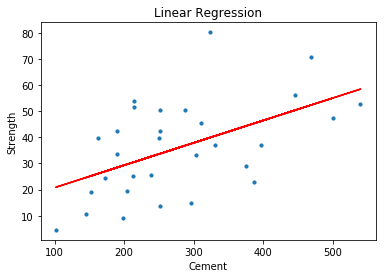

```python
import matplotlib.pyplot as plt
from sklearn.metrics import mean_squared_error, r2_score
model = LinearRegression()
model.fit(x, y)
y_pred = model.predict(x)

rmse = np.sqrt(mean_squared_error(y,y_pred))
r2 = r2_score(y,y_pred)
print("rmse::",rmse)
print("r2::",r2)

plt.scatter(x, y, s=10)
plt.title('Linear Regression')
plt.xlabel('Cement')
plt.ylabel('Strength')
plt.plot(x, y_pred, color='r')
plt.show()
```

```
rmse:: 14.620394832548538
r2:: 0.33203364513645706
```

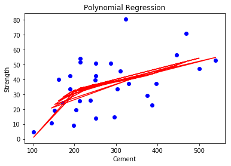

```python
from sklearn.preprocessing import PolynomialFeatures

poly = PolynomialFeatures(degree = 4)
X_poly = poly.fit_transform(x)

poly.fit(X_poly, y)
lin2 = LinearRegression()
lin2.fit(X_poly, y)
y_pred = lin2.predict(poly.fit_transform(x))

rmse = np.sqrt(mean_squared_error(y,y_pred))
r2 = r2_score(y,y_pred)
print("rmse::",rmse)
print("r2::",r2)

plt.scatter(x, y, color = 'blue')

plt.plot(x, y_pred, color = 'red')
plt.title('Polynomial Regression')
plt.xlabel('Cement')
plt.ylabel('Strength')

plt.show()
```

```
rmse:: 17.27402652655191
r2:: 0.06755430144857721
```

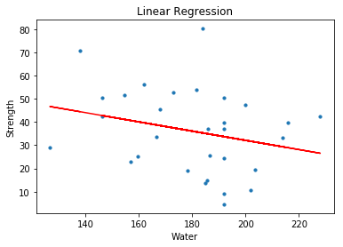

```python
x = datasample.iloc[:,1:2].values
y = datasample.iloc[:,4].values
model = LinearRegression()
model.fit(x, y)
y_pred = model.predict(x)

rmse = np.sqrt(mean_squared_error(y,y_pred))
r2 = r2_score(y,y_pred)
print("rmse::",rmse)
print("r2::",r2)

plt.scatter(x, y, s=10)
plt.title('Linear Regression')
plt.xlabel('Water')
plt.ylabel('Strength')
plt.plot(x, y_pred, color='r')
plt.show()
```

```
rmse:: 16.526442304337348
r2:: 0.14651650087223023
```

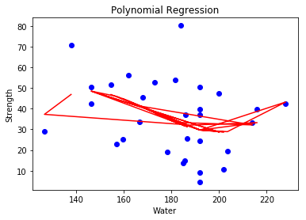

```python
from sklearn.preprocessing import PolynomialFeatures

poly = PolynomialFeatures(degree = 4)
X_poly = poly.fit_transform(x)

poly.fit(X_poly, y)
lin2 = LinearRegression()
lin2.fit(X_poly, y)
y_pred = lin2.predict(poly.fit_transform(x))

rmse = np.sqrt(mean_squared_error(y,y_pred))
r2 = r2_score(y,y_pred)
print("rmse::",rmse)
print("r2::",r2)

plt.scatter(x, y, color = 'blue')

plt.plot(x, y_pred, color = 'red')
plt.title('Polynomial Regression')
plt.xlabel('Water')
plt.ylabel('Strength')

plt.show()
```

```
rmse:: 16.418180496723114
r2:: 0.1576619147166325
```

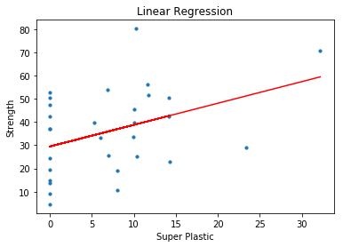

```python
x = datasample.iloc[:,2:3].values
y = datasample.iloc[:,4].values
model = LinearRegression()
model.fit(x, y)
y_pred = model.predict(x)

rmse = np.sqrt(mean_squared_error(y,y_pred))
r2 = r2_score(y,y_pred)
print("rmse::",rmse)
print("r2::",r2)

plt.scatter(x, y, s=10)
plt.title('Linear Regression')
plt.xlabel('Super Plastic')
plt.ylabel('Strength')
plt.plot(x, y_pred, color='r')
plt.show()
```

```
rmse:: 15.62892690912117
r2:: 0.23670097826089276
```

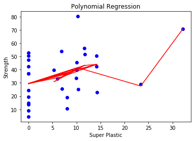

```python
from sklearn.preprocessing import PolynomialFeatures

poly = PolynomialFeatures(degree = 4)
X_poly = poly.fit_transform(x)

poly.fit(X_poly, y)
lin2 = LinearRegression()
lin2.fit(X_poly, y)
y_pred = lin2.predict(poly.fit_transform(x))

rmse = np.sqrt(mean_squared_error(y,y_pred))
r2 = r2_score(y,y_pred)
print("rmse::",rmse)
print("r2::",r2)

plt.scatter(x, y, color = 'blue')

plt.plot(x, y_pred, color = 'red')
plt.title('Polynomial Regression')
plt.xlabel('Super Plastic')
plt.ylabel('Strength')

plt.show()
```

```
rmse:: 14.35579289054281
r2:: 0.3559927539186878
```

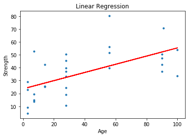

```python
x = datasample.iloc[:,3:4].values
y = datasample.iloc[:,4].values
model = LinearRegression()
model.fit(x, y)
y_pred = model.predict(x)

rmse = np.sqrt(mean_squared_error(y,y_pred))
r2 = r2_score(y,y_pred)
print("rmse::",rmse)
print("r2::",r2)

plt.scatter(x, y, s=10)
plt.title('Linear Regression')
plt.xlabel('Age')
plt.ylabel('Strength')
plt.plot(x, y_pred, color='r')
plt.show()
```

```
rmse:: 12.890028641342036
r2:: 0.4807886827738346
```

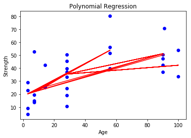

```python
from sklearn.preprocessing import PolynomialFeatures

poly = PolynomialFeatures(degree = 4)
X_poly = poly.fit_transform(x)

poly.fit(X_poly, y)
lin2 = LinearRegression()
lin2.fit(X_poly, y)
y_pred = lin2.predict(poly.fit_transform(x))

rmse = np.sqrt(mean_squared_error(y,y_pred))
r2 = r2_score(y,y_pred)
print("rmse::",rmse)
print("r2::",r2)

plt.scatter(x, y, color = 'blue')

plt.plot(x, y_pred, color = 'red')
plt.title('Polynomial Regression')
plt.xlabel('Age')
plt.ylabel('Strength')

plt.show()
```

From the above polynomial and linear regressions, polynomial regression of degree 4 and above seem to be reducing the RMSE and increasing the R2. So, polynomial of higher degree seem to fit more.

**Gaussian Mixture Models**

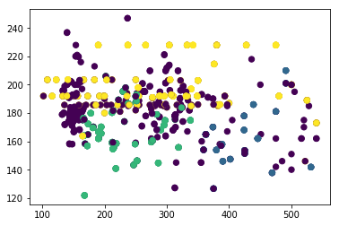

```python
from sklearn.mixture import GaussianMixture
datasample = data


x = datasample.iloc[:,0:4].values
y = datasample.iloc[:,4].values


gmm = GaussianMixture(n_components=4).fit(x)
labels = gmm.predict(x)
plt.scatter(x[:, 0], x[:, 1], c=labels, s=40, cmap='viridis');
```

```python
probs = gmm.predict_proba(x)
print(probs[:100].round(3))
```

```
[[0.945 0.    0.    0.055]
 [0.    0.    1.    0.   ]
 [1.    0.    0.    0.   ]
 [0.97  0.    0.    0.03 ]
 [1.    0.    0.    0.   ]
 [0.    0.    0.    1.   ]
 [0.    0.    0.    1.   ]
 [0.    0.    1.    0.   ]
 [0.919 0.    0.    0.081]
 [1.    0.    0.    0.   ]
 [1.    0.    0.    0.   ]
 [0.    0.    0.    1.   ]
 [0.    0.    0.    1.   ]
 [0.    0.    0.    1.   ]
 [1.    0.    0.    0.   ]
 [0.    0.    1.    0.   ]
 [0.975 0.    0.    0.025]
 [1.    0.    0.    0.   ]
 [0.    0.    1.    0.   ]
 [1.    0.    0.    0.   ]
 [0.    0.    1.    0.   ]
 [0.    0.    0.    1.   ]
 [0.    0.    0.    1.   ]
 [1.    0.    0.    0.   ]
 [0.914 0.    0.    0.086]
 [1.    0.    0.    0.   ]
 [0.    0.    0.    1.   ]
 [0.    0.999 0.001 0.   ]
 [1.    0.    0.    0.   ]
 [1.    0.    0.    0.   ]
 [0.909 0.    0.    0.091]
 [0.863 0.    0.    0.137]
 [1.    0.    0.    0.   ]
 [1.    0.    0.    0.   ]
 [0.    0.    0.    1.   ]
 [1.    0.    0.    0.   ]
 [0.    0.    0.    1.   ]
 [0.    0.001 0.999 0.   ]
 [0.    0.    0.    1.   ]
 [1.    0.    0.    0.   ]
```

[output cut: 45 more lines]

```
 [1.    0.    0.    0.   ]
 [1.    0.    0.    0.   ]
 [0.    0.    1.    0.   ]
 [0.    0.847 0.153 0.   ]
 [0.    0.003 0.997 0.   ]
 [0.    0.    0.    1.   ]
 [0.    0.847 0.153 0.   ]
 [0.    0.    1.    0.   ]
 [0.    0.    0.    1.   ]
 [0.    0.    0.    1.   ]
 [1.    0.    0.    0.   ]
 [1.    0.    0.    0.   ]
 [0.    0.207 0.793 0.   ]
 [1.    0.    0.    0.   ]
 [0.    0.    0.    1.   ]]
```

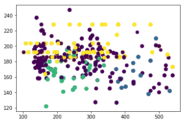

```python
size = 50 * probs.max(1) ** 2  # square emphasizes differences
plt.scatter(x[:, 0], x[:, 1], c=labels, cmap='viridis', s=size);
```

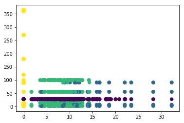

```python
size = 50 * probs.max(1) ** 2  # square emphasizes differences
plt.scatter(x[:, 2], x[:, 3], c=labels, cmap='viridis', s=size);
```

```python
# print the converged log-likelihood value
print(gmm.lower_bound_)

# print the number of iterations needed
# for the log-likelihood value to converge
print(gmm.n_iter_)
```

```
-12.406541043429995
38
```

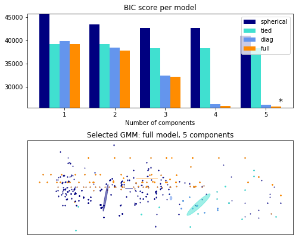

```python
import itertools
from scipy import linalg
import matplotlib as mpl

X=x
lowest_bic = np.infty
bic = []
n_components_range = range(1, 6)
cv_types = ['spherical', 'tied', 'diag', 'full']
for cv_type in cv_types:
    for n_components in n_components_range:
        # Fit a Gaussian mixture with EM
        gmm = GaussianMixture(n_components=n_components,
                                      covariance_type=cv_type)
        gmm.fit(X)
        bic.append(gmm.bic(X))
        if bic[-1] < lowest_bic:
            lowest_bic = bic[-1]
            best_gmm = gmm

bic = np.array(bic)
color_iter = itertools.cycle(['navy', 'turquoise', 'cornflowerblue',
                              'darkorange'])
clf = best_gmm
bars = []

# Plot the BIC scores
plt.figure(figsize=(8, 6))
spl = plt.subplot(2, 1, 1)
for i, (cv_type, color) in enumerate(zip(cv_types, color_iter)):
    xpos = np.array(n_components_range) + .2 * (i - 2)
    bars.append(plt.bar(xpos, bic[i * len(n_components_range):
                                  (i + 1) * len(n_components_range)],
                        width=.2, color=color))
plt.xticks(n_components_range)
plt.ylim([bic.min() * 1.01 - .01 * bic.max(), bic.max()])
plt.title('BIC score per model')
xpos = np.mod(bic.argmin(), len(n_components_range)) + .65 +\
    .2 * np.floor(bic.argmin() / len(n_components_range))
plt.text(xpos, bic.min() * 0.97 + .03 * bic.max(), '*', fontsize=14)
spl.set_xlabel('Number of components')
spl.legend([b[0] for b in bars], cv_types)

# Plot the winner
splot = plt.subplot(2, 1, 2)
Y_ = clf.predict(X)
for i, (mean, cov, color) in enumerate(zip(clf.means_, clf.covariances_,
                                           color_iter)):
    v, w = linalg.eigh(cov)
    if not np.any(Y_ == i):
        continue
    plt.scatter(X[Y_ == i, 0], X[Y_ == i, 1], .8, color=color)

    # Plot an ellipse to show the Gaussian component
    angle = np.arctan2(w[0][1], w[0][0])
    angle = 180. * angle / np.pi  # convert to degrees
    v = 2. * np.sqrt(2.) * np.sqrt(v)
    ell = mpl.patches.Ellipse(mean, v[0], v[1], 180. + angle, color=color)
    ell.set_clip_box(splot.bbox)
    ell.set_alpha(.5)
    splot.add_artist(ell)

plt.xticks(())
plt.yticks(())
plt.title('Selected GMM: full model, 5 components')
plt.subplots_adjust(hspace=.35, bottom=.02)
plt.show()
```

This example shows that model selection can be performed with Gaussian Mixture Models using information-theoretic criteria (BIC). Model selection concerns both the covariance type and the number of components in the model. BIC is better suited if the problem is to identify the right model.